# Part 3 - Automobile Data Preparation - Final - Sheshank

# Gathering Information from the User

```python
##########################################################################
# Function that generates information from the zipfile, keeping it intact but adding additional information
##########################################################################
def figure_out_zip3(zip_file_path):
    #out_list=[]
    information={}# Not used here but can be used later on future for reference and cross checking
    from zipfile import ZipFile
    import numpy as np
    from PIL import Image
    from io import BytesIO
    import cv2 as cv
    import os
    import shutil
    ####################################################
    ####################################################
    file_name=zip_file_path
    myfile=ZipFile(file_name,'r')
    myfile.extractall()
    path=".\\Cars Images"
    images=np.array([])
    information={
    "file_name":[],
    "car_name":[],
    "car_color":[],
    "company":[],
    "type_of_car":[],
    "model_year":[],
    "cc":[],
    "capacity":[]
    }
    #cv.startWindowThread()
    #image_name_list=myfile.infolist().filename
    i=0
    for each in os.listdir(".\\Cars Images"):
        i+=1
        #file_temp=each.filename.split("/")
        img=cv.imread(path+"\\"+each,0)
        #print(type(img))
        #cv.namedWindow("Please enter details for image "+each)
        #cv.imshow(img)
        #cv.waitKey(0)
        print("Observe the car shown and enter the details please\n")
        print(each)
        plt.imshow(img)
        plt.show()
        information["file_name"].append(each)
        information["car_name"].append(input("Please enter the name of the model : \n"))
        information["car_color"].append(input("Please enter the Color of the Car : \n"))
        information["company"].append(input("Please enter the name of the company that manufactured it : \n"))
        information["type_of_car"].append(input("Please enter the type of the car : \n"))
        information["model_year"].append(input("Please enter the model year in which it was released : \n"))
        information["cc"].append(input("Please enter the cc of the car :\n"))
        information["capacity"].append(input("Please enter the seating capacity of the car :\n"))
        #print(img.shape)
        #images=np.append(images,img)
        #out_list.append(img)
        if i==4:
            break;
    #cv.destroyAllWindows()
    #scandir.close()
    shutil.rmtree(path)
    myfile.close()
    #print(images.shape)
    return information #,backup - Uncomment this to collect the file names for cross reference lateron.
##########################################################################
# End of Function
##########################################################################
```

```
Observe the car shown and enter the details please

00001.jpg
```

[figure not shown]

```
Please enter the name of the model :
a
Please enter the Color of the Car :
a
Please enter the name of the company that manufactured it :
a
Please enter the type of the car :
a
Please enter the model year in which it was released :
a
Please enter the cc of the car :
a
Please enter the seating capacity of the car :
a
Observe the car shown and enter the details please

00002.jpg
```

[figure not shown]

```
Please enter the name of the model :
b
Please enter the Color of the Car :
b
Please enter the name of the company that manufactured it :
b
Please enter the type of the car :
b
Please enter the model year in which it was released :
b
Please enter the cc of the car :
b
Please enter the seating capacity of the car :
b
Observe the car shown and enter the details please

00003.jpg
```

[figure not shown]

```
Please enter the name of the model :
c
Please enter the Color of the Car :
c
Please enter the name of the company that manufactured it :
c
Please enter the type of the car :
c
Please enter the model year in which it was released :
c
Please enter the cc of the car :
c
Please enter the seating capacity of the car :
c
Observe the car shown and enter the details please

00004.jpg
```

[figure not shown]

```
Please enter the name of the model :
d
Please enter the Color of the Car :
d
Please enter the name of the company that manufactured it :
d
Please enter the type of the car :
d
Please enter the model year in which it was released :
d
Please enter the cc of the car :
d
Please enter the seating capacity of the car :
d
```

```python
info=figure_out_zip3(file_name)
```

```python
info
```

```
{'file_name': ['00001.jpg', '00002.jpg', '00003.jpg', '00004.jpg'],
 'car_name': ['a', 'b', 'c', 'd'],
 'car_color': ['a', 'b', 'c', 'd'],
 'company': ['a', 'b', 'c', 'd'],
 'type_of_car': ['a', 'b', 'c', 'd'],
 'model_year': ['a', 'b', 'c', 'd'],
 'cc': ['a', 'b', 'c', 'd'],
 'capacity': ['a', 'b', 'c', 'd']}
```

```python
import pandas as pd # This is the most easiest and the simplest
pd.DataFrame(info).to_csv("save.csv")
pd.DataFrame(info)
```

|  | file_name | car_name | car_color | company | type_of_car | model_year | cc | capacity |
| --- | --- | --- | --- | --- | --- | --- | --- | --- |
| 0 | 00001.jpg | a | a | a | a | a | a | a |
| 1 | 00002.jpg | b | b | b | b | b | b | b |
| 2 | 00003.jpg | c | c | c | c | c | c | c |
| 3 | 00004.jpg | d | d | d | d | d | d | d |

```python
len(info)
```

```
8
```

```python
##########################################################################
# Function that exports the gathered information as a csv file in the working directory.
##########################################################################

def dict_in_csv_out(dictionary):
    info=dictionary
    import csv
    with open('saved_data.csv', 'w') as f:
        for key in info.keys():
            f.write(key)
            for each in info[key]:
                f.write(",")
                f.write(each)
            f.write("\n")
        f.close()
##########################################################################
# End of Function
##########################################################################

dict_in_csv_out(info)
```

**Notes** : Though this is done here in the notebook itself simple and easy, we could have easily designed a GUI with tkinter canvas options that will nicely tarverse across the images. Here we don't even have the option of correcting something or the prompt from the user to save the information, asking for rechekcing and verifying. We could have done if wanted, but since it is not asked and confirmation came at last stage, the idea is abandoned.

```python
file_name2="D:\\Work set\\Part-1 - Plant Seedling Classification Data-20210514T160322Z-001.zip"
```

Please use the approrpriate path to the zip file of the data.

```python
# Slightly modified version of the above same function to suit the conditions
##########################################################################
# Function that streams out the entire X_train and y_train kind of mechanism
##########################################################################
def figure_out_zip2(zip_file_path):
    out_list=[]
    labels=[]
    backup=[] # Not used here but can be used later on future for reference and cross checking
    from zipfile import ZipFile
    import numpy as np
    from PIL import Image
    from io import BytesIO
    import cv2 as cv
    ####################################################
    ####################################################
    file_name=zip_file_path
    myfile=ZipFile(file_name,'r')
    images=np.array([])
    #image_name_list=myfile.infolist().filename
    for each in myfile.infolist():
        try:
            file_temp=each.filename.split("/")
            backup.append(file_temp[-1])
            labels.append(file_temp[-2])
            #print(each.filename)
            img=Image.open(BytesIO(myfile.read(each.filename)))
            img=np.array(img)
            #plt.imshow(img)
            #print(img.shape)
            #images=np.append(images,img)
            out_list.append(img)
        except:
            print("Invalid file type",file_temp[-1])
    #print(images.shape)
    myfile.close()
    return out_list,np.array(labels) #,backup - Uncomment this to collect the file names for cross reference lateron.
##########################################################################
# End of Function
##########################################################################
```

```python
photos2,labels2=figure_out_zip2(file_name2)
```

```
Invalid file type .DS_Store
```

```
The Shape is :  (55, 55, 3)

The Name/Class of this particular object is : Scentless Mayweed
```

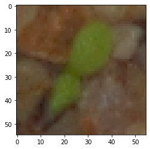

```python
print("\nThe Shape is : ",photos2[12].shape)
print("\nThe Name/Class of this particular object is :",labels2[12])
plt.imshow(photos2[12]) #Demonstration of the photos that we have gathered into the array.
```

```
The Shape is :  (792, 792, 3)

The Name/Class of this particular object is : Small-flowered Cranesbill
```

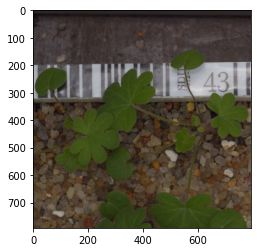

```python
print("\nThe Shape is : ",photos2[88].shape)
print("\nThe Name/Class of this particular object is :",labels2[88])
plt.imshow(photos2[88]) #Demonstration of the photos that we have gathered into the array.
```

The Above didn't pay much attention to the file structure, or whatever it is. We could have made it a little more complicated, which we do make in other projects, but this is just a demonstration. We can make the next step of naming train folder, validate and test sets separately. We can check it out too.

**Suggestions** : We can develop an excellent self-learning mechanism where we first take a few examples, name them painstakingly, and then use it as a feedback to make the machine learn with each sample, like a kind of reinforcement learning, with manual input. We can design a GUI that prompts the user to dictate if what he/she sees is the actual label of that particular object or not. Based on that we might want to run the network with a different and varied batch size to meet the re-correcting of the model.